🏠 Inicio del curso | 📝 Taller repaso 1er Parcial

# Taller repaso 1er Parcial — Técnicas de Optimización y Simulación en Finanzas

## Configuración inicial

**Qué hace**: carga las librerías necesarias para las tres partes del taller (simulación Monte Carlo, descarga de precios reales, portafolios, gráficos).

```r
if (!require("pacman")) install.packages("pacman")
pacman::p_load(tidyverse, EnvStats, ggpubr, psych, quantmod, TTR,
               purrr, PerformanceAnalytics, timetk, readxl, scales)
options(scipen = 999)
```

**Por qué (teoría)**: `EnvStats` trae `rtri()` (la distribución triangular que pide la Parte 1), `PerformanceAnalytics` calcula retornos de portafolio con rebalanceo, y `quantmod` descarga precios reales de Yahoo Finance para la Parte 2.

```r
# NOTA: EnvStats cargado junto con tidyverse/ggplot2 rompe la dispatch de
# print() sobre objetos ggplot (ggplot2 4.x usa el sistema S7; ver
# CLAUDE.md del proyecto) — se dibuja el grob directamente en vez de
# depender de print()/de que el chunk auto-imprima.
dibujar <- function(p) {
  grid::grid.newpage()
  grid::grid.draw(ggplot2::ggplotGrob(p))
}
```

# Parte 1 — Selección de una inversión

> “Se te ha asignado la tarea de invertir un capital de USD$20,000 en un activo de renta variable a un periodo de un año. Después de explorar y filtrar diferentes opciones, estás considerando 3 posibilidades:
> 1. Una inversión que genera retornos anuales y que se espera sigan una distribución normal con una media de 6.5 % y una desviación estándar de 14 %.
> 2. Un activo con retornos mensuales, los cuales siguen una distribución triangular con un mínimo de -8.5 %, un máximo de 6.5 % y una moda de 0.56 %.
> 3. Un activo con retornos trimestrales, estos siguen una distribución normal con una media de 1.6 % y una desviación estándar de 7 %.”

## Simulación de las 3 inversiones (10,001 iteraciones)

**Qué hace**: simula el capital final a 1 año para cada inversión. (a) es de un solo periodo (ya es anual, un solo `rnorm()` por escenario); (b) y (c) necesitan **componer varios periodos dentro del mismo año** (12 meses y 4 trimestres respectivamente) — se genera una matriz de retornos aleatorios (filas = escenarios, columnas = periodos) y se capitaliza cada fila con producto acumulado (`cumprod`), guardando la trayectoria completa (no solo el capital final) porque la Pregunta 3 pide graficar la evolución periodo a periodo de la inversión elegida.

**Por qué (teoría)**: capitalizar $n$ retornos periódicos compuestos equivale a $C_T = C_0 \prod_{t=1}^{n}(1+r_t)$ — el mismo principio de interés compuesto que enlaza distintas frecuencias de retorno (diario, semanal, mensual…), visto ya en la unidad de Portafolio.

```r
capital_inicial_1 <- 20000
n_sim_1 <- 10001
semilla_1 <- 2026

## a. Normal anual: media 6.5%, sd 14% (1 solo periodo)
set.seed(semilla_1)
retorno_a <- rnorm(n_sim_1, mean = 0.065, sd = 0.14)
capital_a <- capital_inicial_1 * (1 + retorno_a)

## b. Triangular mensual: min -8.5%, max 6.5%, moda 0.56% (12 meses compuestos)
set.seed(semilla_1)
retorno_b <- matrix(EnvStats::rtri(n_sim_1 * 12, min = -0.085, max = 0.065, mode = 0.0056),
                     nrow = n_sim_1, ncol = 12)
capital_b_trayectoria <- capital_inicial_1 * t(apply(1 + retorno_b, 1, cumprod))
capital_b <- capital_b_trayectoria[, 12]

## c. Normal trimestral: media 1.6%, sd 7% (4 trimestres compuestos)
set.seed(semilla_1)
retorno_c <- matrix(rnorm(n_sim_1 * 4, mean = 0.016, sd = 0.07), nrow = n_sim_1, ncol = 4)
capital_c_trayectoria <- capital_inicial_1 * t(apply(1 + retorno_c, 1, cumprod))
capital_c <- capital_c_trayectoria[, 4]

medidas_inversion <- function(capital_final, capital_inicial, alpha_var = 0.01) {
  VaR_q <- quantile(capital_final, probs = alpha_var)
  ic95 <- quantile(capital_final, probs = c(0.025, 0.975))
  data.frame(
    capital_promedio = mean(capital_final),
    capital_maximo = max(capital_final),
    ganancia_maxima = max(capital_final) - capital_inicial,
    capital_minimo = min(capital_final),
    perdida_maxima = capital_inicial - min(capital_final),
    mediana = median(capital_final),
    ic95_inf = ic95[1],
    ic95_sup = ic95[2],
    VaR_99 = capital_inicial - VaR_q,
    ES_99 = capital_inicial - mean(capital_final[capital_final < VaR_q])
  )
}

tabla_inversiones <- bind_rows(
  cbind(inversion = "a. Normal anual", medidas_inversion(capital_a, capital_inicial_1)),
  cbind(inversion = "b. Triangular mensual", medidas_inversion(capital_b, capital_inicial_1)),
  cbind(inversion = "c. Normal trimestral", medidas_inversion(capital_c, capital_inicial_1))
)
tabla_inversiones %>% mutate(across(where(is.numeric), ~ round(.x, 2)))
```

|  | inversion | capital_promedio | capital_maximo | ganancia_maxima | capital_minimo | perdida_maxima | mediana | ic95_inf | ic95_sup | VaR_99 | ES_99 |
| --- | --- | --- | --- | --- | --- | --- | --- | --- | --- | --- | --- |
| 2.5%...1 | a. Normal anual | 21310.17 | 32076.10 | 12076.10 | 11010.92 | 8989.08 | 21293.83 | 15852.90 | 26830.59 | 5147.74 | 5948.15 |
| 2.5%...2 | b. Triangular mensual | 18900.44 | 29253.31 | 9253.31 | 12903.18 | 7096.82 | 18811.16 | 15093.59 | 23135.10 | 5507.04 | 5976.41 |
| 2.5%...3 | c. Normal trimestral | 21345.73 | 36685.20 | 16685.20 | 12092.28 | 7907.72 | 21196.45 | 15932.73 | 27519.53 | 4973.30 | 5763.37 |

## Pregunta 1 — Las 7 medidas por inversión

> “1. Para cada una de estas inversiones deberá de calcular las siguientes medidas, usando una simulación de 10,001 iteraciones en cada uno de los casos.
> 1. Capital promedio al final del año.
> 2. Capital máximo al final de la inversión y cuanta ganancia genero.
> 3. Capital mínimo al final de la inversión y cuanta perdida genero.
> 4. La mediana del capital al final del año.
> 5. Intervalo del 95 % de los capitales alrededor del capital final promedio.
> 6. El valor en riesgo con una confianza del 99 %.
> 7. La pérdida esperada con una confianza del 99 %.

> Para una de las inversiones, debe de interpretar cada una de las medidas.”

**Respuesta:** la tabla de arriba (`tabla_inversiones`) tiene una fila por inversión con las 7 medidas: capital promedio, capital máximo y su ganancia, capital mínimo y su pérdida, mediana, intervalo del 95 % (percentil 2.5 %–97.5 % del capital simulado), VaR al 99 % y ES al 99 % (los dos últimos expresados como pérdida en dólares respecto al capital inicial).

### Interpretación de las 7 medidas — inversión (a) Normal anual

```r
m_a <- medidas_inversion(capital_a, capital_inicial_1)
```

**1. Capital promedio al final del año**: $21,310.17 — en promedio, sobre las 10001 trayectorias simuladas, los $20,000 invertidos terminan valiendo $21,310.17 (una ganancia esperada de $1,310.17).

**2. Capital máximo**: $32,076.10 — el mejor de los 10001 escenarios simulados, con una ganancia de $12,076.10 sobre el capital inicial.

**3. Capital mínimo**: $11,010.92 — el peor de los 10001 escenarios, con una pérdida de $8,989.08. El capital nunca se vuelve negativo porque esta inversión es de un solo periodo (un retorno anual negativo, por muy malo que sea, deja algo de capital mientras no sea peor que -100 %).

**4. Mediana**: $21,293.83 — el valor que divide en dos mitades iguales los 10001 resultados simulados. Queda muy cerca del promedio ($21,310.17) porque el retorno subyacente es **normal**, una distribución simétrica.

**5. Intervalo del 95 %**: $15,852.90 a $26,830.59 — el 95 % de los capitales finales simulados cae dentro de ese rango; solo el 2.5 % de las peores corridas termina por debajo de $15,852.90, y el 2.5 % de las mejores por encima de $26,830.59.

**6. VaR al 99 %**: la pérdida máxima de la inversión, con un 99 % de confianza en el año, es de USD $5,147.74. Hay una probabilidad del 1 % de que las pérdidas de la inversión sean mayores a USD $5,147.74.

**7. ES al 99 %**: la pérdida esperada al 99 % en el año es de USD $5,948.15 — es decir, si el escenario cae dentro de ese peor 1 % de los casos, la pérdida **promedio** ahí es de $5,948.15, mayor que el VaR porque promedia toda la cola de pérdidas, no solo su borde.

## Pregunta 2 — Decisión de inversión

> “2. Una vez calculadas las medidas, debe de definir en cuál de las opciones invertirá su capital. Esto considerando como criterio de decisión el valor de la perdida esperada en un contexto de aversión al riesgo. Justifique su decisión”

```r
inversion_elegida <- tabla_inversiones$inversion[which.min(tabla_inversiones$ES_99)]
tabla_inversiones %>% select(inversion, capital_promedio, ES_99) %>%
  mutate(across(where(is.numeric), ~round(.x, 2)))
```

|  | inversion | capital_promedio | ES_99 |
| --- | --- | --- | --- |
| 2.5%...1 | a. Normal anual | 21310.17 | 5948.15 |
| 2.5%...2 | b. Triangular mensual | 18900.44 | 5976.41 |
| 2.5%...3 | c. Normal trimestral | 21345.73 | 5763.37 |

**Respuesta:** se elige la inversión **c. Normal trimestral**. Su ES al 99 % es $5,763.37 — el más bajo de las 3 (vs. $5,948.15 de la Normal anual y $5,976.41 de la Triangular mensual). En un contexto de aversión al riesgo, donde el criterio de decisión es la pérdida esperada en el peor escenario (no solo el retorno promedio), esta es la opción más defendible: además de tener la **menor** pérdida esperada en el 1 % de peores casos, también tiene el **mayor** capital promedio esperado ($21,345.73) de las 3 — no hay ningún trade-off que resolver, domina en las dos dimensiones a la vez.

## Pregunta 3 — Gráfico de la iteración máxima, mínima y mediana

> “3. Finalmente, para la inversión que ha decidido es la mejor opción, realice un gráfico donde se muestre la iteración que generó el máximo capital, la que generó el mínimo capital y la que generó el capital considerado la mediana de los resultados de las iteraciones.”

**Qué hace**: identifica, dentro de las 10001 simulaciones de la inversión elegida, cuál escenario terminó con el capital máximo, cuál con el mínimo, y cuál quedó más cerca de la mediana — y grafica la trayectoria **completa** (trimestre a trimestre, no solo el resultado final) de esas tres iteraciones puntuales.

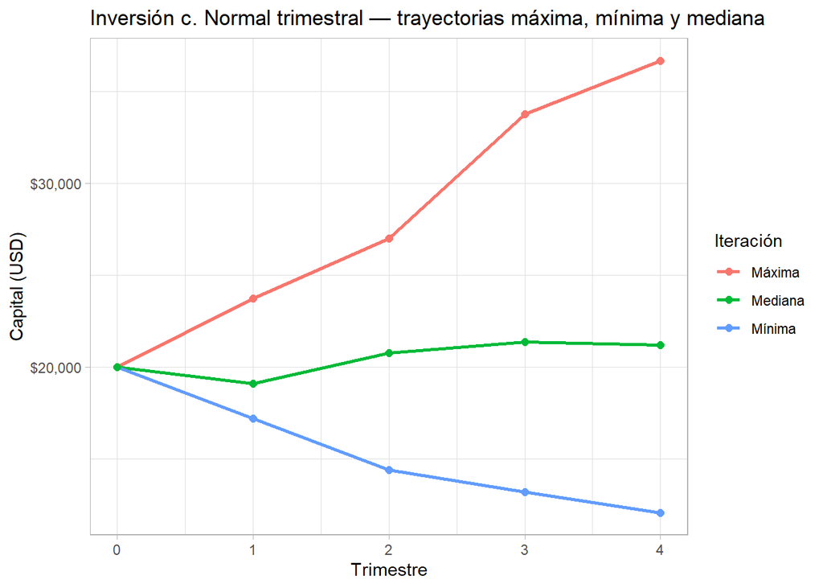

```r
idx_max_c <- which.max(capital_c)
idx_min_c <- which.min(capital_c)
idx_mediana_c <- which.min(abs(capital_c - median(capital_c)))

trayectorias_c <- bind_rows(
  data.frame(trimestre = 0:4, capital = c(capital_inicial_1, capital_c_trayectoria[idx_max_c, ]), iteracion = "Máxima"),
  data.frame(trimestre = 0:4, capital = c(capital_inicial_1, capital_c_trayectoria[idx_min_c, ]), iteracion = "Mínima"),
  data.frame(trimestre = 0:4, capital = c(capital_inicial_1, capital_c_trayectoria[idx_mediana_c, ]), iteracion = "Mediana")
)

dibujar(ggplot(trayectorias_c, aes(x = trimestre, y = capital, color = iteracion)) +
  geom_line(linewidth = 0.9) +
  geom_point(size = 2) +
  theme_light() +
  labs(title = "Inversión c. Normal trimestral — trayectorias máxima, mínima y mediana",
       x = "Trimestre", y = "Capital (USD)", color = "Iteración") +
  scale_y_continuous(labels = label_dollar()) +
  scale_x_continuous(breaks = 0:4))
```

**Respuesta:** el gráfico de arriba muestra, trimestre a trimestre (0 a 4), la trayectoria de la iteración 1645 (capital final máximo, $36,685.20), la iteración 3569 (capital final mínimo, $12,092.28) y la iteración 557 (capital más cercano a la mediana, $21,196.45), todas partiendo de los $20,000 iniciales en el trimestre 0.

# Parte 2 — Retornos y distribuciones

> “Empleando estas acciones [AVGO, LLY, WMT, V, MA, COST, MRK, PM, TXN, PEP, DIS, SBUX], descargue los precios para el periodo: 31/12/2022 - 31/08/2026. A partir de esta información, calcule los retornos semanales de cada una de las acciones.”

## Descarga de precios y retornos semanales

**Qué hace**: descarga el precio de cierre ajustado de las 12 acciones vía `quantmod::getSymbols()`, convierte a frecuencia semanal (`xts::to.weekly()`) y calcula el retorno logarítmico semanal.

**Por qué (teoría)**: se usa `diff(log(x))` en vez de `TTR::ROC()` — con la misma combinación de librerías de este taller (`tidyverse` + `EnvStats` + `PerformanceAnalytics` + `quantmod`/`TTR`), `TTR::ROC()` sobre un objeto de `to.weekly()` puede crashear R sin ningún mensaje de error (bug ya documentado en el `CLAUDE.md` del proyecto, reproducido con datos sintéticos). `diff(log(x))` calcula exactamente el mismo retorno continuo ($\ln(P_t/P_{t-1})$) sin ese problema.

```r
tickers_2 <- c("AVGO", "LLY", "WMT", "V", "MA", "COST", "MRK", "PM", "TXN", "PEP", "DIS", "SBUX")

precios_2 <- quantmod::getSymbols(tickers_2, src = "yahoo",
                                  from = "2022-12-31", to = "2026-08-31",
                                  periodicity = "daily",
                                  auto.assign = TRUE, warnings = FALSE) %>%
  purrr::map(~quantmod::Ad(get(.))) %>%
  purrr::reduce(merge.xts) %>%
  `colnames<-`(tickers_2)

precios_semana_2 <- xts::to.weekly(precios_2, OHLC = FALSE)
retornos_semana_2 <- diff(log(precios_semana_2)) %>% na.omit()

retornos_semana_2_long <- retornos_semana_2 %>% tk_tbl(rename_index = "date") %>%
  gather(key = activo, value = retorno, -date, factor_key = TRUE)

cat("Precios:", format(zoo::index(precios_2)[1]), "a",
    format(zoo::index(precios_2)[nrow(precios_2)]), "-", nrow(precios_2), "días\n")
```

```
## Precios: 2023-01-03 a 2026-08-28 - 917 días
```

```r
cat("Retornos semanales:", nrow(retornos_semana_2), "semanas, de",
    format(zoo::index(retornos_semana_2)[1]), "a",
    format(zoo::index(retornos_semana_2)[nrow(retornos_semana_2)]))
```

```
## Retornos semanales: 190 semanas, de 2023-01-13 a 2026-08-28
```

## Pregunta 1 — Histograma agrupado, no superpuesto

> “1. Realiza el histograma de los retornos semanales de todas las acciones. Agrupado, pero no superpuesto.”

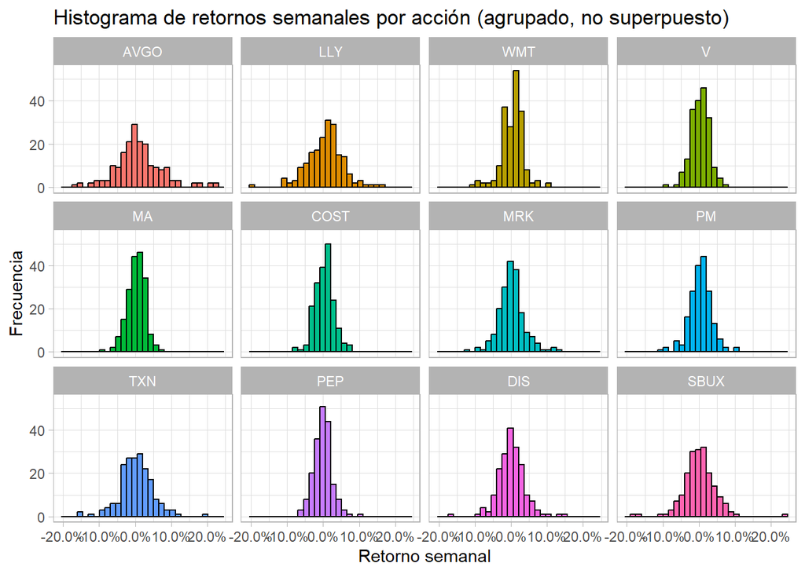

```r
dibujar(retornos_semana_2_long %>%
  ggplot(aes(x = retorno, fill = activo)) +
  geom_histogram(bins = 30, color = "black") +
  facet_wrap(~activo, ncol = 4) +
  theme_light() +
  theme(legend.position = "none") +
  labs(title = "Histograma de retornos semanales por acción (agrupado, no superpuesto)",
       x = "Retorno semanal", y = "Frecuencia") +
  scale_x_continuous(labels = label_percent(0.1)))
```

**Respuesta:** el gráfico de arriba usa `facet_wrap()` — un panel por acción, cada uno con su propio histograma — en vez de superponer varias acciones en el mismo eje (que sería `position = "identity"` con transparencia). “Agrupado” se cumple porque las 12 acciones comparten la misma cuadrícula de paneles y el mismo eje x, permitiendo compararlas lado a lado sin que sus barras se mezclen.

## Pregunta 2 — Densidades

> “2. Realiza el gráfico de las densidades de los retornos.”

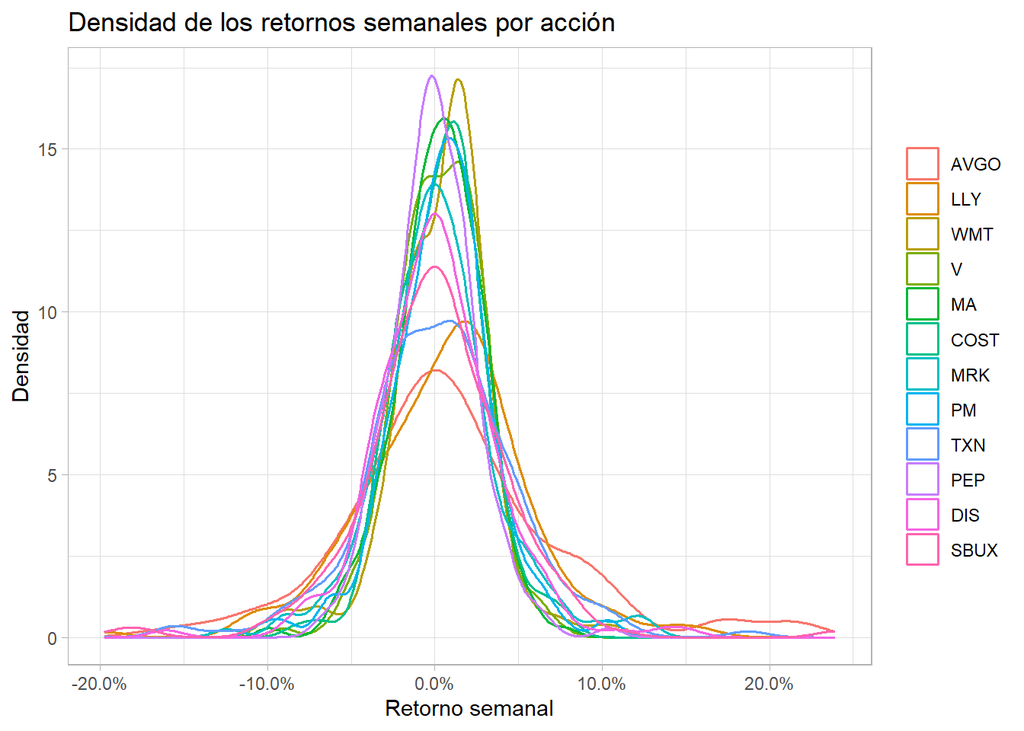

```r
dibujar(retornos_semana_2_long %>%
  ggplot(aes(x = retorno, color = activo)) +
  geom_density(linewidth = 0.7) +
  theme_light() +
  labs(title = "Densidad de los retornos semanales por acción",
       x = "Retorno semanal", y = "Densidad", color = NULL) +
  scale_x_continuous(labels = label_percent(0.1)))
```

**Respuesta:** a diferencia del histograma agrupado, aquí las 12 densidades sí se superponen en el mismo gráfico — es la forma natural de comparar dispersión y forma entre acciones sin que 12 paneles separados dificulten la comparación visual.

## Pregunta 3 — Evolución de los retornos (gráfico de líneas)

> “3. Realiza el gráfico de líneas que muestre la evolución de los retornos de las acciones.”

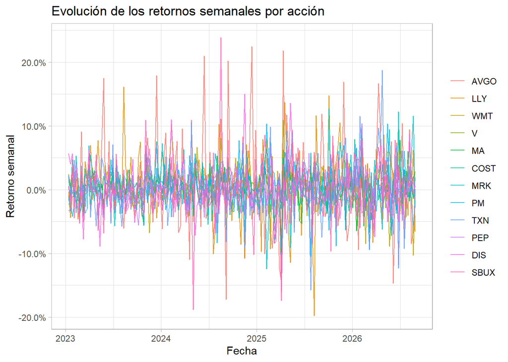

```r
dibujar(retornos_semana_2_long %>%
  ggplot(aes(x = date, y = retorno, color = activo)) +
  geom_line(linewidth = 0.4, alpha = 0.8) +
  theme_light() +
  labs(title = "Evolución de los retornos semanales por acción",
       x = "Fecha", y = "Retorno semanal", color = NULL) +
  scale_y_continuous(labels = label_percent(0.1)))
```

**Respuesta:** el gráfico de líneas de arriba muestra la evolución semana a semana de los retornos de las 12 acciones sobre el mismo eje de tiempo (2023-01-13 a 2026-08-28) — útil para detectar episodios donde varias acciones se mueven juntas (semanas de volatilidad de mercado generalizada).

## Pregunta 4 — Portafolio con rebalanceo anual

> “4. Usando estas acciones, construye un portafolio con una composición de tu elección. Calcula los retornos históricos, con rebalanceos anuales, del portafolio.”

**Qué hace**: asigna pesos de **convicción decreciente** (mismo criterio ya usado en `Portafolio/taller/Taller_Portafolio.R`) — más peso a las acciones que encabezan la lista, menos a las últimas — y calcula el retorno histórico del portafolio con `PerformanceAnalytics::Return.portfolio()`, rebalanceando la composición a los pesos objetivo una vez al año.

```r
pesos_portafolio <- rev(seq_along(tickers_2)) / sum(seq_along(tickers_2))
names(pesos_portafolio) <- tickers_2

data.frame(accion = tickers_2, peso = label_percent(accuracy = 0.01)(pesos_portafolio))
```

|  | accion | peso |
| --- | --- | --- |
| AVGO | AVGO | 15.38% |
| LLY | LLY | 14.10% |
| WMT | WMT | 12.82% |
| V | V | 11.54% |
| MA | MA | 10.26% |
| COST | COST | 8.97% |
| MRK | MRK | 7.69% |
| PM | PM | 6.41% |
| TXN | TXN | 5.13% |
| PEP | PEP | 3.85% |

[output cut: 2 more lines]

```r
portafolio_2 <- PerformanceAnalytics::Return.portfolio(R = retornos_semana_2,
                                                        weights = pesos_portafolio,
                                                        rebalance_on = "years") %>%
  `colnames<-`("retornos")

retorno_acumulado_portafolio <- prod(1 + as.numeric(portafolio_2)) - 1
```

**Respuesta:** portafolio con pesos de convicción decreciente (15.4% en AVGO hasta 1.3% en SBUX), rebalanceado cada año. Retorno semanal promedio = 0.42%, desviación estándar semanal = 2.02%, retorno acumulado total del periodo (190 semanas) = 113.56%.

# Parte 3 — Evaluación de Proyectos

> “Usted dispone de un capital de $500 millones. Existe la posibilidad de invertir en un proyecto que tiene una duración de 5 años, con flujos evaluados semestralmente. La tasa de descuento es del 12 % EA. Existen dos posibilidades para realizar la inversión:

> **Sector Agrotecnológico**: en este proyecto, los costos administrativos están controlados, pero los ingresos dependen de la volatilidad del precio internacional del grano.
> - Ingresos (t = 1…10): Siguen una distribución Lognormal, donde la media de los ingresos semestrales es 18.181 y la desviación estándar es 0.186.
> - Costos (t = 1…10): Siguen una distribución Normal, con media de $30M y desviación estándar de $1M.

> **Sector Infraestructura**: en este proyecto, los ingresos están asegurados por contratos estatales, pero los costos de materiales y administración son altamente inciertos.
> - Ingresos (t = 1…10): Siguen una distribución Normal, con media de $75M y desviación estándar de $1.5M.
> - Costos (t = 1…10): Siguen una distribución Lognormal, donde la media de la normal asociada de los costos semestrales es 17.014 y la desviación estándar de la normal asociada es 0.456.”

## Simulación del VPN (100,000 iteraciones)

**Nota de supuesto**: el enunciado dice explícitamente “media de la **normal asociada**” para los costos de Infraestructura (es decir, 17.014 y 0.456 son los parámetros `meanlog`/`sdlog` de la lognormal, no la media/sd en dólares) pero no lo repite para el ingreso de Agrotecnológico. Se asume la misma convención en ambos casos, porque la magnitud de los números lo deja claro: una lognormal con `meanlog = 18.181, sdlog = 0.186` tiene una media real de $e^{18.181+0.186^2/2}\approx\$80$M por semestre — del mismo orden que el ingreso de $75M/semestre de Infraestructura. Leer 18.181 como la media en dólares **directa** haría que el ingreso de Agrotecnológico fuera de apenas $18.18, absurdo frente a un costo de $30M/semestre. Los resultados de `rlnorm()` se dividen entre `1e6` para expresarlos en millones de dólares, la misma unidad que el resto del ejercicio.

**Qué hace**: simula, para cada proyecto, el flujo de caja neto (ingresos − costos) en cada uno de los 10 semestres, lo descuenta a valor presente a la tasa **semestral** equivalente al 12 % EA ($ (1.12)^{0.5}-1 $), y resta la inversión inicial de $500M para obtener el VPN de cada una de las 100,000 iteraciones.

```r
inv_inicial_3 <- 500          # millones de USD
tasa_ea_3 <- 0.12
r_semestral_3 <- (1 + tasa_ea_3)^0.5 - 1
n_sim_3 <- 100000
n_sem_3 <- 10
factor_descuento_3 <- (1 + r_semestral_3)^(1:n_sem_3)

set.seed(2026)
ingresos_agro <- matrix(rlnorm(n_sim_3 * n_sem_3, meanlog = 18.181, sdlog = 0.186),
                        nrow = n_sim_3, ncol = n_sem_3) / 1e6
costos_agro <- matrix(rnorm(n_sim_3 * n_sem_3, mean = 30, sd = 1), nrow = n_sim_3, ncol = n_sem_3)
flujo_agro <- ingresos_agro - costos_agro
vpn_agro <- -inv_inicial_3 + rowSums(sweep(flujo_agro, 2, factor_descuento_3, "/"))

# misma semilla para que ambos proyectos usen el mismo stream de numeros
# aleatorios - comparacion mas limpia entre los dos escenarios
set.seed(2026)
ingresos_infra <- matrix(rnorm(n_sim_3 * n_sem_3, mean = 75, sd = 1.5), nrow = n_sim_3, ncol = n_sem_3)
costos_infra <- matrix(rlnorm(n_sim_3 * n_sem_3, meanlog = 17.014, sdlog = 0.456),
                       nrow = n_sim_3, ncol = n_sem_3) / 1e6
flujo_infra <- ingresos_infra - costos_infra
vpn_infra <- -inv_inicial_3 + rowSums(sweep(flujo_infra, 2, factor_descuento_3, "/"))

resumen_vpn <- function(vpn, alpha = 0.05) {
  VaR_q <- quantile(vpn, alpha)
  data.frame(
    vpn_promedio = mean(vpn),
    vpn_sd = sd(vpn),
    vpn_mediana = median(vpn),
    vpn_min = min(vpn),
    vpn_max = max(vpn),
    prob_vpn_negativo_pct = mean(vpn < 0) * 100,
    VaR_5 = VaR_q,
    ES_5 = mean(vpn[vpn < VaR_q])
  )
}

tabla_vpn <- bind_rows(
  cbind(proyecto = "Agrotecnológico", resumen_vpn(vpn_agro)),
  cbind(proyecto = "Infraestructura", resumen_vpn(vpn_infra))
)
tabla_vpn %>% mutate(across(where(is.numeric), ~round(.x, 2)))
```

|  | proyecto | vpn_promedio | vpn_sd | vpn_mediana | vpn_min | vpn_max | prob_vpn_negativo_pct | VaR_5 | ES_5 |
| --- | --- | --- | --- | --- | --- | --- | --- | --- | --- |
| 5%...1 | Agrotecnológico | -128.54 | 35.70 | -129.70 | -266.46 | 49.89 | 99.95 | -185.20 | -198.26 |
| 5%...2 | Infraestructura | -145.23 | 31.17 | -142.75 | -394.05 | -36.90 | 100.00 | -200.26 | -218.09 |

## Pregunta 1 — Histograma de las distribuciones del VPN

> “1. Realice y analice el histograma de las distribuciones de los VPN para ambas inversiones.”

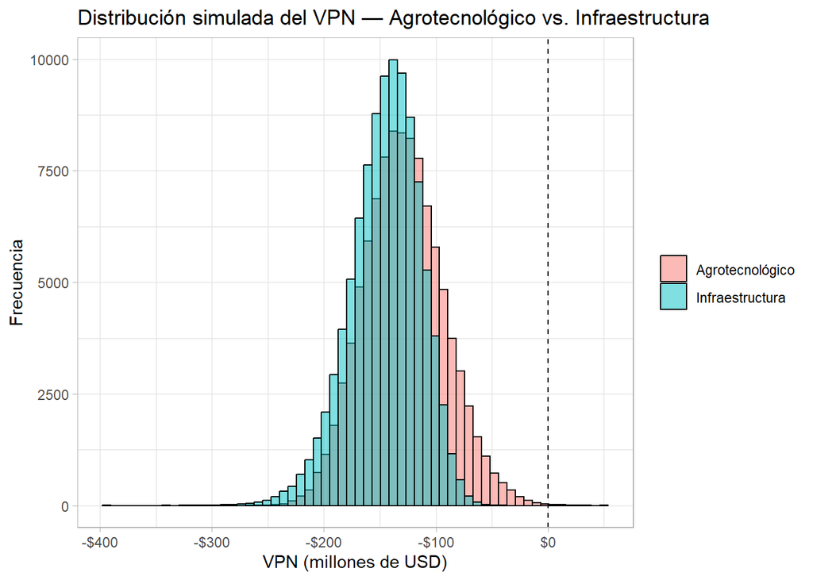

```r
vpn_long <- bind_rows(
  data.frame(vpn = vpn_agro, proyecto = "Agrotecnológico"),
  data.frame(vpn = vpn_infra, proyecto = "Infraestructura")
)

dibujar(ggplot(vpn_long, aes(x = vpn, fill = proyecto)) +
  geom_histogram(position = "identity", alpha = 0.5, color = "black", bins = 60) +
  theme_light() +
  geom_vline(xintercept = 0, linetype = "dashed") +
  labs(title = "Distribución simulada del VPN — Agrotecnológico vs. Infraestructura",
       x = "VPN (millones de USD)", y = "Frecuencia", fill = NULL) +
  scale_x_continuous(labels = label_dollar()))
```

## Pregunta 2 — VaR y ES al 5 %

> “2. Calcule el VaR al 5 % y el ES al 5 % del VPN de ambas inversiones. Interprete los resultados.”

**Respuesta:**

- **Agrotecnológico:** el VPN, con un 95 % de confianza en el horizonte del proyecto, no cae por debajo de USD -$185.20 millones. Hay una probabilidad del 5 % de que el VPN sea peor que eso. Si efectivamente cae en ese 5 % de peores escenarios, el VPN esperado ahí (ES) es de USD -$198.26 millones.
- **Infraestructura:** con un 95 % de confianza, el VPN no cae por debajo de USD -$200.26 millones (probabilidad del 5 % de que sea peor). En el 5 % de peores escenarios, el VPN esperado (ES) es de USD -$218.09 millones.

Infraestructura tiene tanto un VaR como un ES más negativos que Agrotecnológico — en el escenario adverso, se pierde más dinero con Infraestructura.

## Pregunta 3 — Decisión según el VPN promedio

> “3. Teniendo en cuenta el VPN promedio de los proyectos como criterio de decisión ¿En cual de los dos proyectos invertiría el capital disponible?”

```r
proyecto_mejor_vpn <- tabla_vpn$proyecto[which.max(tabla_vpn$vpn_promedio)]
```

**Respuesta:** por VPN promedio, **Agrotecnológico** es la **menos mala** opción (-$128.54 millones vs. -$145.23 millones del otro). **Pero** el VPN promedio de las **dos** opciones es negativo — ninguno de los dos proyectos es rentable en promedio con estos parámetros. Si el criterio es únicamente cuál proyecto es “menos malo”, se elige Agrotecnológico; si el criterio es invertir solo en proyectos con VPN promedio **positivo**, la respuesta correcta es **no invertir en ninguno de los dos**.

## Pregunta 4 — Condición del comité de riesgos (probabilidad de VPN negativo < 10 %)

> “4. Resulta que el comité de riesgos de las empresa que diriges te ha puesto la condición de que solo inviertas en proyectos cuya probabilidad de tener un VPN negativo sea menor al 10 %. Considerando esta condición ¿Invertirías en los proyectos disponibles?”

**Respuesta:** **no** se invertiría en ninguno de los dos proyectos bajo esta condición. La probabilidad de VPN negativo es 99.95 % en Agrotecnológico y 100 % en Infraestructura — ambas muy por encima del límite del 10 % que exige el comité (de hecho, ambas superan el 99 %: con estos parámetros, casi cualquier escenario simulado termina en pérdida). Ningún proyecto pasa el filtro de riesgo.

## Pregunta 5 — ¿Rentable en promedio pero peligroso en escenarios extremos?

> “5. Usando el VPN promedio de los proyectos y el ES calculado ¿Es el proyecto rentable en promedio pero excesivamente peligroso en escenarios extremos?”

**Respuesta:** **no** aplica esa lectura para ninguno de los dos proyectos — esa pregunta describe un proyecto con VPN promedio **positivo** pero un ES muy negativo (rentable en el caso base, peligroso en la cola). Acá el problema es anterior a eso: el VPN promedio **ya** es negativo (-$128.54 millones en Agrotecnológico, -$145.23 millones en Infraestructura), así que no hay un escenario “base rentable” que el ES esté poniendo en riesgo — ambos proyectos ya son perdedores en promedio, y el ES (-$198.26 y -$218.09 millones respectivamente) solo confirma que en el peor 5 % de los casos la pérdida es todavía mayor.